# Data Visualization Bootcamp homework

Thunkarn V.

2023-10-03

# Introduction

This report is part of DataRockie Bootcamp 8 in the data visualization sprint. We studied and analyzed the Diamonds dataset to learn more about the relationships between the parameters.

## Data overview

quick overview of a data frame

```r
library(tidyverse)
glimpse(diamonds)
```

```
## Rows: 53,940
## Columns: 10
## $ carat   <dbl> 0.23, 0.21, 0.23, 0.29, 0.31, 0.24, 0.24, 0.26, 0.22, 0.23, 0.…
## $ cut     <ord> Ideal, Premium, Good, Premium, Good, Very Good, Very Good, Ver…
## $ color   <ord> E, E, E, I, J, J, I, H, E, H, J, J, F, J, E, E, I, J, J, J, I,…
## $ clarity <ord> SI2, SI1, VS1, VS2, SI2, VVS2, VVS1, SI1, VS2, VS1, SI1, VS1, …
## $ depth   <dbl> 61.5, 59.8, 56.9, 62.4, 63.3, 62.8, 62.3, 61.9, 65.1, 59.4, 64…
## $ table   <dbl> 55, 61, 65, 58, 58, 57, 57, 55, 61, 61, 55, 56, 61, 54, 62, 58…
## $ price   <int> 326, 326, 327, 334, 335, 336, 336, 337, 337, 338, 339, 340, 34…
## $ x       <dbl> 3.95, 3.89, 4.05, 4.20, 4.34, 3.94, 3.95, 4.07, 3.87, 4.00, 4.…
## $ y       <dbl> 3.98, 3.84, 4.07, 4.23, 4.35, 3.96, 3.98, 4.11, 3.78, 4.05, 4.…
## $ z       <dbl> 2.43, 2.31, 2.31, 2.63, 2.75, 2.48, 2.47, 2.53, 2.49, 2.39, 2.…
```

### Question 1

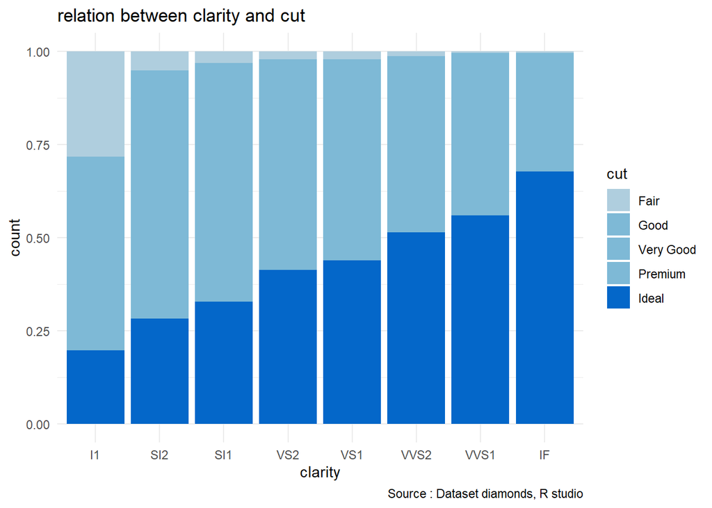

```r
## relation between clarity and cut
library(ggplot2)
ggplot(diamonds, aes(x=clarity, fill = cut)) +
  geom_bar(position = "fill") +
  theme_minimal() +
  scale_fill_manual(values =
                      c("#afcede", "#7eb9d6", "#7eb9d6",
                        "#7eb9d6", "#0467c9")) +
  labs(
    title = "relation between clarity and cut",
    caption = "Source : Dataset diamonds, R studio"
  )
```

From this bar chart we found that the higher clarity, the better cut quality of the diamonds

### Question 2

Color VS price

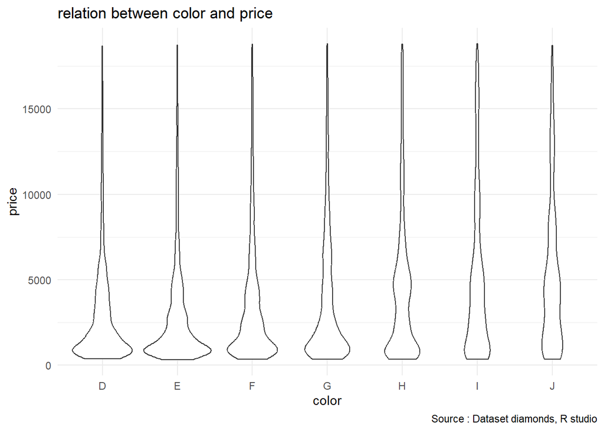

```r
## relation between color and price
ggplot(diamonds, aes(x=color, y=price)) +
  geom_violin() +
  theme_minimal() +
    labs(
    title = "relation between color and price",
    caption = "Source : Dataset diamonds, R studio"
    )
```

```r
diamonds %>%
  group_by(color) %>%
  summarise(
    median(price),
    mean(price),
    min(price),
    max(price)
  )
```

| color | median(price) | mean(price) | min(price) | max(price) |
| --- | --- | --- | --- | --- |
| D | 1838.0 | 3169.954 | 357 | 18693 |
| E | 1739.0 | 3076.752 | 326 | 18731 |
| F | 2343.5 | 3724.886 | 342 | 18791 |
| G | 2242.0 | 3999.136 | 354 | 18818 |
| H | 3460.0 | 4486.669 | 337 | 18803 |
| I | 3730.0 | 5091.875 | 334 | 18823 |
| J | 4234.0 | 5323.818 | 335 | 18710 |

The violin plot above shows that color quality is significantly related to price. However, the minimum and maximum data suggest that there may be another factor involved.

Question 3 Carat VS Price

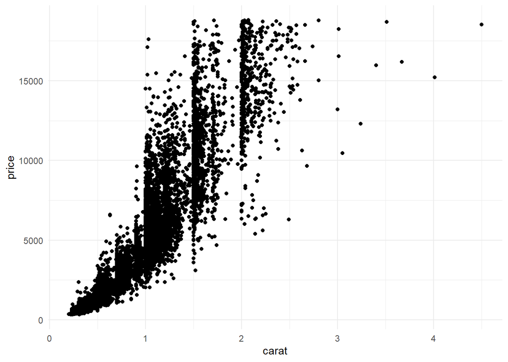

```r
set.seed(43)
 sample_diamonds <- sample_frac(diamonds, 0.25)

ggplot(sample_diamonds, aes(x=carat, y=price)) +
  geom_point() +
  theme_minimal()
```

```r
sample_diamonds %>%
  select(carat,price) %>%
  cor()
```

```
##           carat     price
## carat 1.0000000 0.9222735
## price 0.9222735 1.0000000
```

The scatter plot above shows that carat has a significant effect on the price of diamonds. This is also confirmed by the correlation between carat and price, which is very close to one.

### Question 4

Clarity VS Price(without considering carat)

```r
set.seed(43)
 sample_diamonds <- sample_frac(diamonds, 0.25)

sample_diamonds2 <- sample_diamonds %>%
  mutate(price_per_carat = price/carat)
```

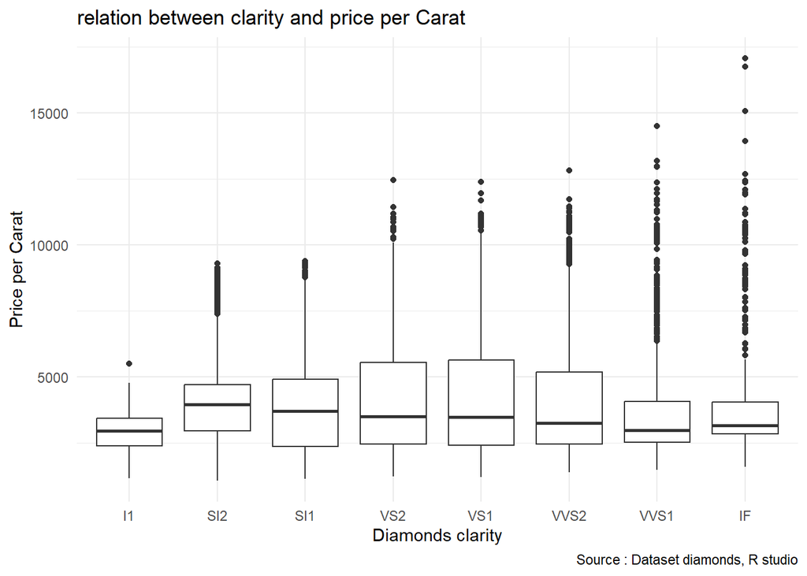

```r
ggplot(sample_diamonds2, aes(x=clarity, y=price_per_carat))+
  geom_boxplot() +
  theme_minimal() +
      labs(
    title = "relation between clarity and price per Carat",
    caption = "Source : Dataset diamonds, R studio",
    x = "Diamonds clarity",
    y = "Price per Carat"
    )
```

```r
sample_diamonds2 %>%
  group_by(clarity) %>%
  summarise(
    median = round(median(price_per_carat)),
    average = round(mean(price_per_carat)),
    min = round(min(price_per_carat)),
    max= round(max(price_per_carat))
  )
```

| clarity | median | average | min | max |
| --- | --- | --- | --- | --- |
| I1 | 2957 | 2898 | 1168 | 5494 |
| SI2 | 3965 | 3990 | 1081 | 9306 |
| SI1 | 3712 | 3842 | 1139 | 9395 |
| VS2 | 3494 | 4126 | 1226 | 12461 |
| VS1 | 3487 | 4198 | 1215 | 12403 |
| VVS2 | 3260 | 4247 | 1400 | 12819 |
| VVS1 | 2981 | 3838 | 1487 | 14498 |
| IF | 3158 | 4168 | 1604 | 17078 |

The box plot above shows that without considering the Carat factor, clarity has no relation with price. This conclusion is also confirmed by the summary table.

### Question 5

Depth VS Price(without considering carat) split by cut type

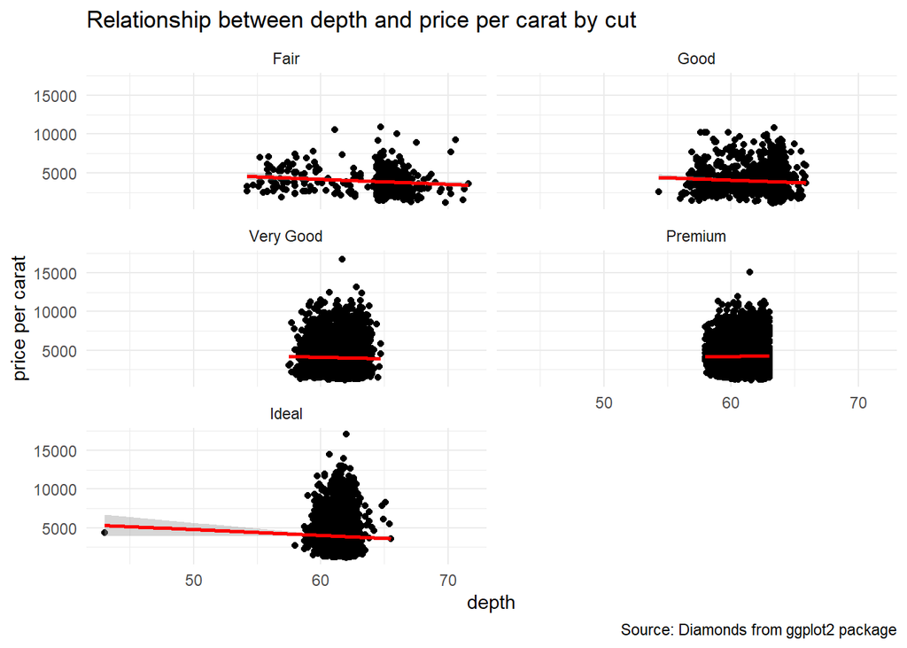

```r
ggplot(sample_diamonds2, aes(x=depth, y=price_per_carat)) +
  geom_point() +
  geom_smooth(method = "lm", col="red") +
  facet_wrap(~cut, ncol=2) +
  theme_minimal() +
    labs(title = "Relationship between depth and price per carat by cut",
       x = "depth",
       y = "price per carat",
       caption = "Source: Diamonds from ggplot2 package")
```

```r
sample_diamonds2 %>%
  select(price_per_carat, depth) %>%
  cor()
```

```
##                 price_per_carat       depth
## price_per_carat      1.00000000 -0.04022711
## depth               -0.04022711  1.00000000
```

The scatter plot above shows that depth has very little relation with price per carat. This is also confirmed by the correlation coefficient, which is lower than 0.5.